# Project 6: Randomization and Matching

# Introduction

In this project, you will explore the question of whether college education causally affects political participation. Specifically, you will use replication data from by former Berkeley PhD students John Henderson and Sara Chatfield. Their paper is itself a replication study of by Cindy Kam and Carl Palmer. In their original 2008 study, Kam and Palmer argue that college education has no effect on later political participation, and use the propensity score matching to show that pre-college political activity drives selection into college and later political participation. Henderson and Chatfield in their 2011 paper argue that the use of the propensity score matching in this context is inappropriate because of the bias that arises from small changes in the choice of variables used to model the propensity score. They use (at that point a new method), which uses an approach similar to optimal matching to optimize Mahalanobis distance weights. Even with genetic matching, they find that balance remains elusive however, thus leaving open the question of whether education causes political participation.

You will use these data and debates to investigate the benefits and pitfalls associated with matching methods. Replication code for these papers is available online, but as you’ll see, a lot has changed in the last decade or so of data science! Throughout the assignment, use tools we introduced in lab from the and the packages. Specifically, try to use dplyr, tidyr, purrr, stringr, and ggplot instead of base R functions. While there are other matching software libraries available, MatchIt tends to be the most up to date and allows for consistent syntax.

# Data

Otherwise, we also have covariates measured for survey responses to various questions about political attitudes. We have covariates measured for the students in the baseline year, covariates for their parents in the baseline year, and covariates from follow-up surveys. . In general, post-treatment covariates will be clear from the name (i.e. student_1973Married indicates whether the student was married in the 1973 survey). Be mindful that the baseline covariates were all measured in 1965, the treatment occurred between 1965 and 1973, and the outcomes are from 1973 and beyond. We will distribute the Appendix from Henderson and Chatfield that describes the covariates they used, but please reach out with any questions if you have questions about what a particular variable means.

```r
# Load tidyverse and MatchIt
# Feel free to load other libraries as you wish
library(tidyverse)
library(MatchIt)
library(cobalt)
# Load ypsps data
ypsps <- read_csv('data/ypsps.csv')
head(ypsps)
```

| interviewid | college | student_vote | student_meeting | student_other | student_button | student_money | student_communicate | student_demonstrate | student_community | student_ppnscal | student_PubAff | student_Newspaper | student_Radio | student_TV | student_Magazine | student_FamTalk | student_FrTalk | student_AdultTalk | student_PID | student_SPID | student_GovtOpinion | student_GovtCrook | student_GovtWaste | student_TrGovt | student_GovtSmart | student_Govt4All | student_Cynic | student_LifeWish | student_GLuck | … |
| --- | --- | --- | --- | --- | --- | --- | --- | --- | --- | --- | --- | --- | --- | --- | --- | --- | --- | --- | --- | --- | --- | --- | --- | --- | --- | --- | --- | --- | --- | --- |
| 1 | 1 | 1 | 0 | 0 | 0 | 0 | 0 | 1 | 1 | 3 | 1 | 1 | 1 | 3 | 1 | 1 | 2 | 4 | 2 | 2 | 2 | 2 | 2 | 2 | 1 | 2 | 3 | 1 | 1 | … |
| 2 | 1 | 1 | 1 | 1 | 1 | 0 | 1 | 1 | 1 | 7 | 1 | 2 | 5 | 2 | 1 | 1 | 1 | 2 | 1 | 3 | 1 | 2 | 3 | 2 | 1 | 3 | 3 | 1 | 1 | … |
| 3 | 1 | 1 | 0 | 0 | 1 | 0 | 0 | 0 | 0 | 2 | 1 | 2 | 1 | 3 | 1 | 1 | 2 | 3 | 6 | 2 | 1 | 2 | 2 | 2 | 3 | 2 | 6 | 1 | 2 | … |
| 4 | 0 | 0 | 0 | 0 | 0 | 0 | 1 | 0 | 1 | 2 | 1 | 2 | 1 | 5 | 1 | 1 | 1 | 1 | 3 | 1 | 1 | 2 | 2 | 2 | 1 | 3 | 3 | 3 | 3 | … |
| 5 | 1 | 1 | 1 | 0 | 0 | 0 | 1 | 0 | 0 | 3 | 1 | 1 | 1 | 2 | 1 | 1 | 1 | 2 | 1 | 3 | 1 | 2 | 2 | 1 | 1 | 3 | 2 | 1 | 1 | … |
| 6 | 1 | 1 | 0 | 0 | 0 | 1 | 0 | 0 | 0 | 2 | 0 | 2 | 1 | 5 | 3 | 4 | 4 | 4 | 6 | 2 | 3 | 2 | 2 | 1 | 1 | 3 | 2 | 1 | 1 | … |

# Randomization

Matching is usually used in observational studies to to approximate random assignment to treatment. But could it be useful even in randomized studies? To explore the question do the following:

```r
set.seed(1234)
n <- dim(ypsps)[1]

# Generate a vector that randomly assigns each unit to treatment/control
ypsps <- ypsps %>% mutate(Treatment = as.numeric(rbernoulli(n)))
# Choose a baseline covariate (use dplyr for this)
ypsps %>% select(student_Gen, Treatment)
```

| student_Gen | Treatment |
| --- | --- |
| 0 | 0 |
| 0 | 1 |
| 1 | 1 |
| 0 | 1 |
| 0 | 1 |
| 1 | 1 |
| 0 | 0 |
| 1 | 0 |
| 1 | 1 |
| 1 | 1 |

[output cut: 1244 more lines]

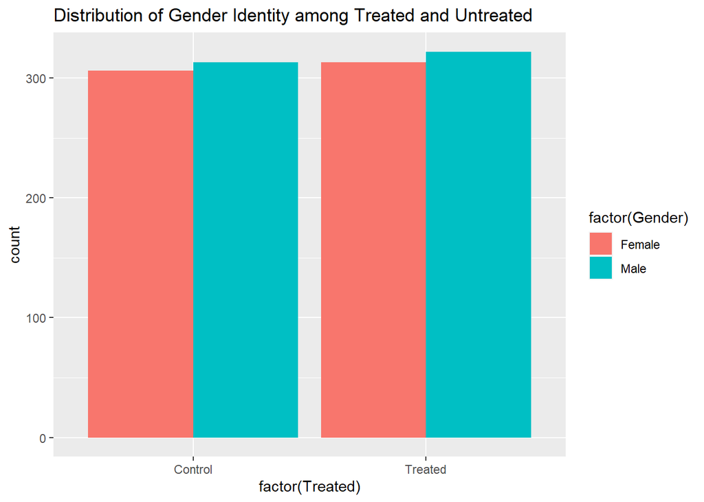

```r
# Visualize the distribution by treatment/control (ggplot)
ggplot(ypsps %>% mutate(
  Gender = ifelse(student_Gen == 1, "Male", "Female"),
  Treated = ifelse(Treatment == 1, "Treated", "Control")
)
,
aes(x = factor(Treated), fill = factor(Gender))) +
  geom_bar(position = "dodge") +
  #facet_grid(Treatment~.) +
  labs(title = "Distribution of Gender Identity among Treated and Untreated")
```

```r
subset <- ypsps %>% select(student_Gen)

subset %>%
  mutate(Treatment = as.numeric(rbernoulli(n))) %>%
  group_by(Treatment) %>%
  summarize(mean = mean(student_Gen))
```

| Treatment | mean |
| --- | --- |
| 0 | 0.4792994 |
| 1 | 0.5335463 |

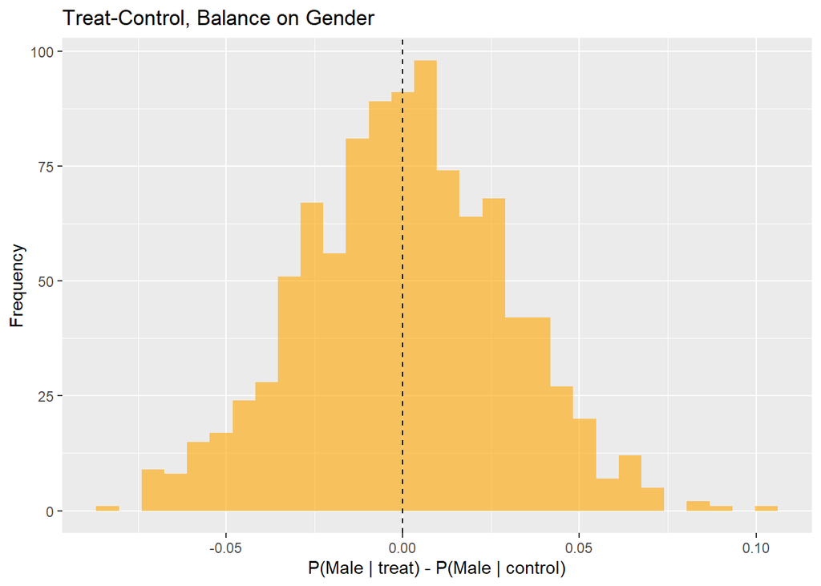

```r
set.seed(1234)
# Simulate this 10,000 times (monte carlo simulation - see R Refresher for a hint)
differences <- c()
subset <- ypsps %>% select(student_Gen)

for (i in 1:1000){
  ypsps_mc <- subset %>% mutate(Treatment = as.numeric(rbernoulli(n)))
  treat_proportion <- ypsps_mc %>%
    group_by(Treatment) %>%
    summarise(mean_out = mean(student_Gen)) %>%
    subset(Treatment == 1) %>% select(mean_out) %>%
    max()
  control_proportion <- ypsps_mc %>%
    group_by(Treatment) %>%
    summarise(mean_out = mean(student_Gen)) %>%
    subset(Treatment == 0) %>% select(mean_out) %>%
    max()
  differences[i] <- treat_proportion - control_proportion
}

ggplot(data = data.frame(x = differences), aes(x = x)) +
  geom_histogram(bins=30, fill="orange", alpha=.6) +
  geom_vline(xintercept=0, linetype = "dashed") +
  labs(title = "Treat-Control, Balance on Gender", x = "P(Male | treat) - P(Male | control)", y = "Frequency")
```

## One Model

Select covariates that you think best represent the “true” model predicting whether a student chooses to attend college, and estimate a propensity score model to calculate the Average Treatment Effect on the Treated (ATT). Plot the balance of the top 10 (or fewer if you select fewer covariates). Report the balance of the p-scores across both the treatment and control groups, and using a threshold of standardized mean difference of p-score $\leq .1$, report the number of covariates that meet that balance threshold.

```r
# Select covariates that represent the "true" model for selection, fit model
model_data <- ypsps %>%
  select(college,
         student_ppnscal,
         student_Gen,
         student_Race,
         student_GPA,
         parent_HHInc,
         parent_EducW,
         parent_EducHH)

model_ps <-
  matchit(
    formula = college ~ student_Gen + student_Race + student_GPA +
      parent_HHInc + parent_EducW + parent_EducHH,
    data = model_data,
    method = "nearest",
    distance = "glm",
    link="logit",
    estimand = "ATT"
  )
match_exact_ate_data <- match.data(model_ps)
lm_att <-
  lm(
    student_ppnscal ~ college + student_Gen + student_Race + student_GPA +
      parent_HHInc + parent_EducW + parent_EducHH,
    data = match_exact_ate_data,
    weights = weights
  )
att_ps <- lm_att$coefficients['college1']
att_ps
```

```
## <NA>
##   NA
```

```
## No `var.name` was provided. Displaying balance for distance.
```

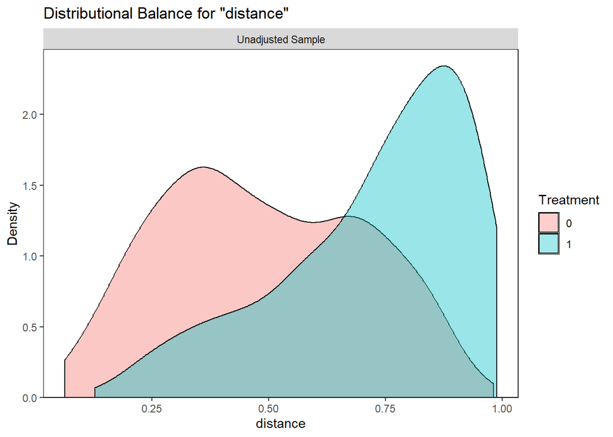

```r
bal.plot(model_ps, which = 'unadjusted')
```

```r
out <- bal.tab(model_ps, binary = "std", threshold = 0.1)
out
```

```
## Balance Measures
##                   Type Diff.Adj        M.Threshold
## distance      Distance   1.9101
## student_Gen     Binary   0.3341 Not Balanced, >0.1
## student_Race   Contin.  -0.0727     Balanced, <0.1
## student_GPA    Contin.  -0.8298 Not Balanced, >0.1
## parent_HHInc   Contin.   1.0642 Not Balanced, >0.1
## parent_EducW   Contin.   1.1467 Not Balanced, >0.1
## parent_EducHH  Contin.   1.3672 Not Balanced, >0.1
##
## Balance tally for mean differences
##                    count
## Balanced, <0.1         1
## Not Balanced, >0.1     5
##
## Variable with the greatest mean difference
##       Variable Diff.Adj        M.Threshold
##  parent_EducHH   1.3672 Not Balanced, >0.1
##
## Sample sizes
##           Control Treated
## All           451     803
## Matched       451     451
## Unmatched       0     352
```

## Simulations

Henderson/Chatfield argue that an improperly specified propensity score model can actually the bias of the estimate. To demonstrate this, they simulate 800,000 different propensity score models by choosing different permutations of covariates. To investigate their claim, do the following:

```r
# Remove post-treatment covariates
ypsps_clean <- ypsps %>%
  select(-c(
    matches("_19\\d\\d"),
    'interviewid',
    'Treatment',
    matches('\\wPlacebo')
  ))

# Simulate random selection of features 10k+ times
atts <- c()
prop_balanced <- c()
percent_imp <- c()

for (i in 1:100) {
  # Randomly select features
  colnames <- sample(names(ypsps_clean %>% select(-c(
    student_ppnscal, college
  ))),
  sample(2:ncol(ypsps_clean), 1) - 1)
  independent <- paste(colnames, collapse = " + ")
  ps_formula <- as.formula(paste("college ~", independent))
  # Fit p-score models and save ATTs, proportion of balanced covariates, and mean percent balance improvement
  model_ps <-
    matchit(
      replace = TRUE,
      formula = ps_formula,
      data = ypsps_clean,
      method = "nearest",
      ratio = 1,
      distance = "glm",
      link = "logit",
      estimand = "ATT",
    )
  lm_att <-
    lm(
      student_ppnscal ~ college + student_Gen + student_Race + student_GPA +
        parent_HHInc + parent_EducW + parent_EducHH,
      data = match.data(model_ps),
      weights = weights
    )
  out <- bal.tab(model_ps, threshold = .1)
  att_ps <- lm_att$coefficients['college']
  atts[i] <- att_ps
  prop_balanced[i] <- out$Balanced.mean.diffs['Balanced, <0.1', ] /
    out$Balanced.mean.diffs %>% sum()
  pre <- data.frame(summary(model_ps)$sum.all) %>%
    pull(Std..Mean.Diff.) %>%
    mean()
  post <- data.frame(summary(model_ps)$sum.matched) %>%
    pull(Std..Mean.Diff.) %>%
    mean()
  percent_imp[i] <- (post - pre) / pre
}
```

```r
sim_results <- data.frame(atts, prop_balanced, percent_imp)

sim_results %>% filter(prop_balanced > 2/29) %>% nrow()
```

```
## [1] 100
```

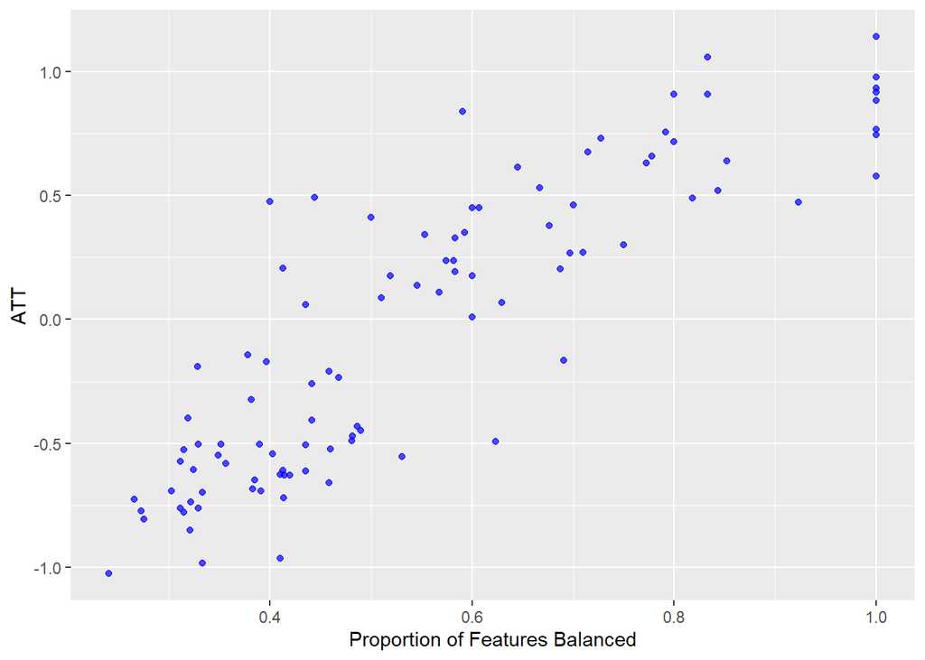

```r
# Plot ATT v. proportion
# Customize the scatterplot
ggplot(sim_results, aes(x = prop_balanced, y = atts)) +
  geom_point(color = "blue",
             fill = "blue",
             alpha = .7) +
  labs(x = "Proportion of Features Balanced", y = "ATT")
```

# Matching Algorithm of Your Choice

## Simulate Alternative Model

Henderson/Chatfield propose using genetic matching to learn the best weights for Mahalanobis distance matching. Choose a matching algorithm other than the propensity score (you may use genetic matching if you wish, but it is also fine to use the greedy or optimal algorithms we covered in lab instead). Repeat the same steps as specified in Section 4.2 and answer the following questions:

```r
# Simulate random selection of features 10k+ times
atts <- c()
prop_balanced <- c()
percent_imp <- c()

for (i in 1:100) {
  # Randomly select features
  colnames <- sample(names(ypsps_clean %>% select(-c(
    student_ppnscal, college
  ))),
  sample(2:ncol(ypsps_clean), 1) - 1)
  independent <- paste(colnames, collapse = " + ")
  ps_formula <- as.formula(paste("college ~", independent))
  # Fit p-score models and save ATTs, proportion of balanced covariates, and mean percent balance improvement
  model_ps <-
    matchit(
      formula = ps_formula,
      data = ypsps_clean,
      method = "quick",
      ratio = 1,
      distance = "glm",
      link = "logit",
      estimand = "ATT",
    )
  lm_att <-
    lm(
      student_ppnscal ~ college + student_Gen + student_Race + student_GPA +
        parent_HHInc + parent_EducW + parent_EducHH,
      data = match.data(model_ps),
      weights = weights
    )
  out <- bal.tab(model_ps, threshold = .1)
  att_ps <- lm_att$coefficients['college']
  atts[i] <- att_ps
  prop_balanced[i] <- out$Balanced.mean.diffs['Balanced, <0.1', ] /
    out$Balanced.mean.diffs %>% sum()
  pre <- data.frame(summary(model_ps)$sum.all) %>%
    pull(Std..Mean.Diff.) %>%
    mean()
  post <- data.frame(summary(model_ps)$sum.matched) %>%
    pull(Std..Mean.Diff.) %>%
    mean()
  percent_imp[i] <- (post - pre) / pre
}
```

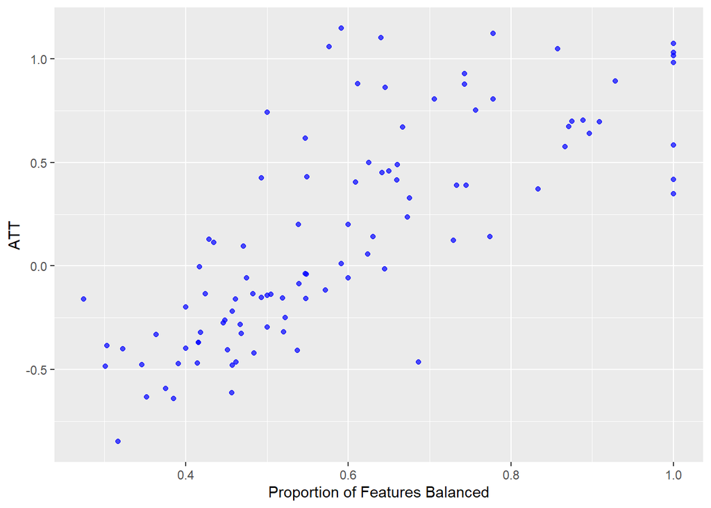

```r
# Visualization for distributions of percent improvement
sim_results <- data.frame(atts, prop_balanced, percent_imp)

ggplot(sim_results, aes(x = prop_balanced, y = atts)) +
  geom_point(color = "blue",
             fill = "blue",
             alpha = .7) +
  labs(x = "Proportion of Features Balanced", y = "ATT")
```